# PARTIE II: EXPLORATION Ford GoBike

## PAR: Ngan Desire

## Resume de l'enquete

Notre enquete a porté sur le comportement des membres des courses à velo suivant le genre(homme,femme,autre).L'attribut d'interet principal s'est porté sur **member_gender** pour comprendre les habitudes de consommation des differents genres.Pour ce faire apres le nettoyage nous nous sommes appuye sur les attributs suivants:**duration_sec,la distance_travel,bike_id,user_type,age_member,start_time_weekdays, start_time_hour et enfin bike_share_for_all_trip**. A l'issue de l'analyse exploratoire nous avons tiré quelques conclusions importantes que nous allons explorer en détails dans la présentatin suivantes:

```
''
```

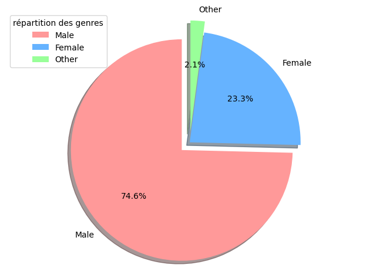

```
''
```

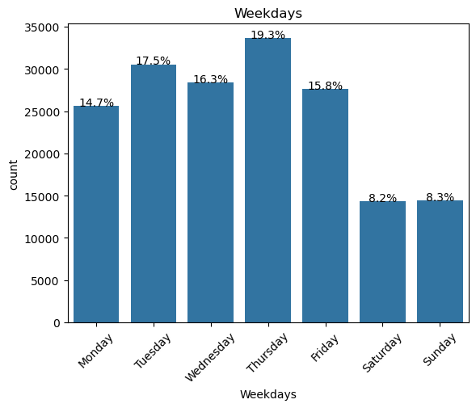

```
''
```

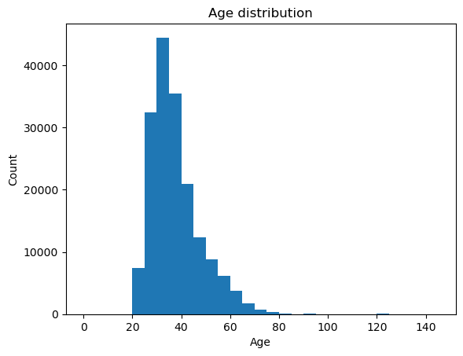

**La grande majorité des genres est représenté le jeudi et les hommes sont les plus nombreux a chacun de ces jours.En revanche on peut remarquer que les memebres appartenant au genre (autre) particpent de facon contante a chacune des courses.Chacun des genres particpent de la meme maniere les samedis et les dimanches.**

```
''
```

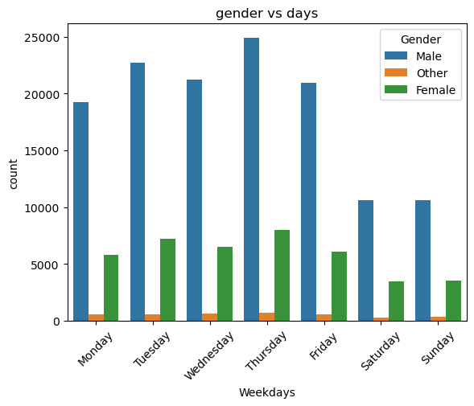

```
''
```

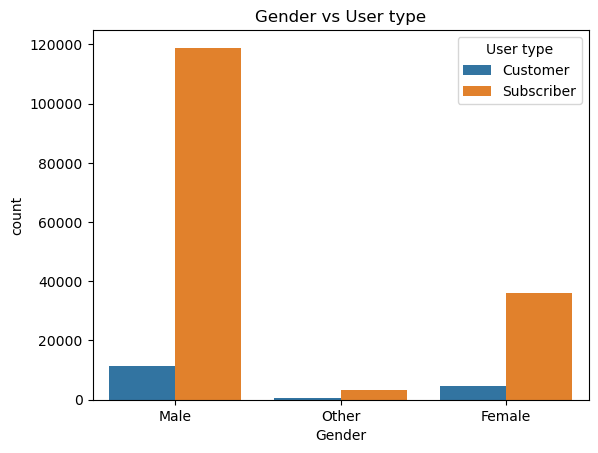

**On remarque qu'en considérant la durée des courses par semaine en moyenne les membres avec un autre genre durent beaucoup plus longtemps que les hommes et les femmes**

```
''
```

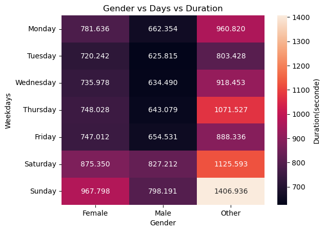